# DENETİMLİ MAKİNA ÖĞRENMESİ

## 2.2.Regresyon Ağacı(RT)

```r
library(tree)
library(psych)
model_rt <- tree(rings~.,data=egitim_data)
summary(model_rt)
```

```
##
## Regression tree:
## tree(formula = rings ~ ., data = egitim_data)
## Variables actually used in tree construction:
## [1] "shell_weight"   "shucked_weight"
## Number of terminal nodes:  8
## Residual mean deviance:  5.682 = 16560 / 2915
## Distribution of residuals:
##    Min. 1st Qu.  Median    Mean 3rd Qu.    Max.
## -6.6000 -1.4080 -0.4079  0.0000  0.9606 13.1200
```

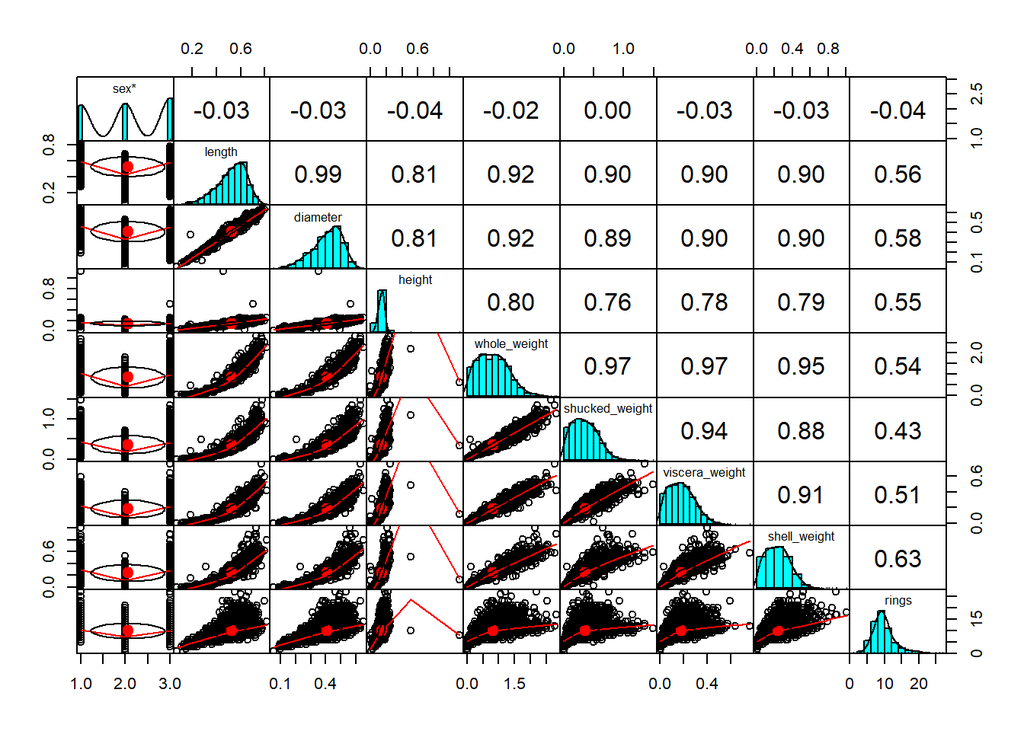

```r
pairs.panels(egitim_data,gap=0,pch=21)
```

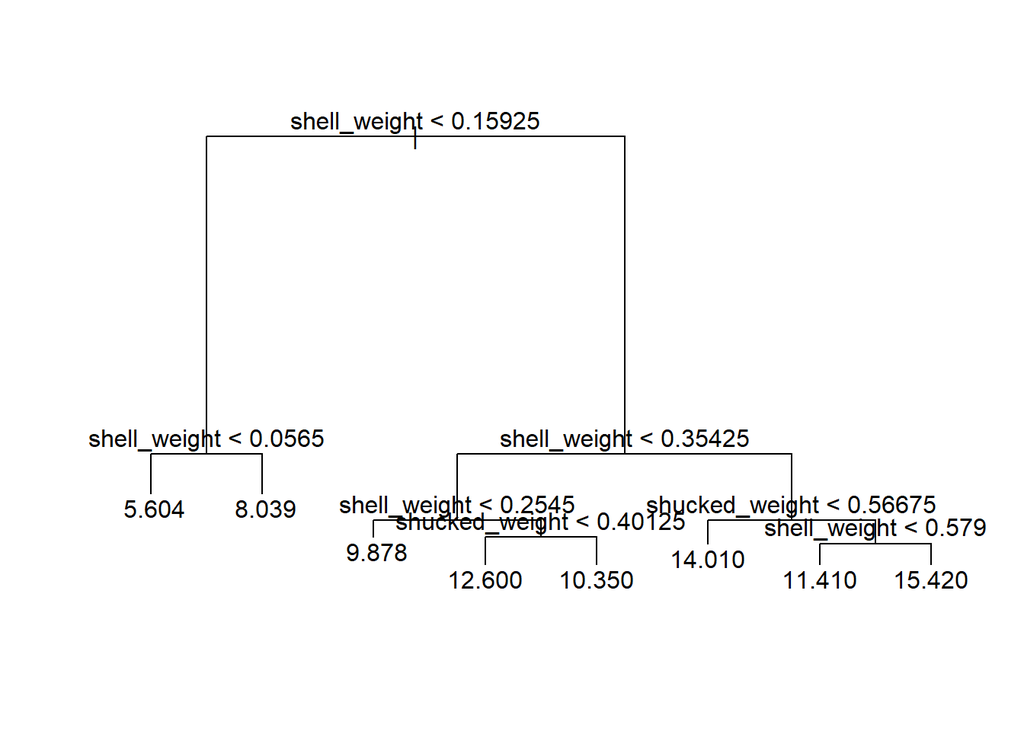

```r
plot(model_rt)
text(model_rt,pretty=0)
```

Tree fonksiyonu ile rings bağımlı değişkeni ile diğer tüm bağımsız değişkenler arasındaki ilişkiyi modelleyen bir regresyon ağacı modeli oluşturduk. Regresyon ağacının oluşturulmasında “shell_weight” ve “shucked_weight” değişkenleri kullanılmıştır. Shell_wieght değişkeni y’i en iyi açıklayan değişkendir. Number of terminal nodes, ağacın kaç terminal düğüm içerdiğini belirtmektedir. Bu durumda, ağacımızda 8 terminal düğüm bulunmaktadır. Residual mean deviance, modelin kalıntılarının ortalamasının deviance (sapma) değerini belirtir. Daha düşük değer, modelin verilere daha iyi uyum sağladığını gösterebilir. Bu durumda, 5.682 olarak verilmiştir.

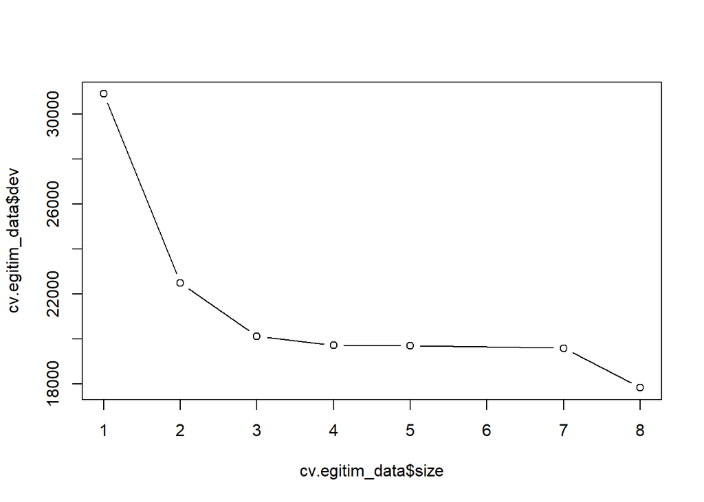

```r
cv.egitim_data <- cv.tree(model_rt)
plot(cv.egitim_data$size,cv.egitim_data$dev,type="b")
```

```r
prune_model_rt=prune.tree(model_rt,best=4)
summary(prune_model_rt)
```

```
##
## Regression tree:
## snip.tree(tree = model_rt, nodes = 6:7)
## Variables actually used in tree construction:
## [1] "shell_weight"
## Number of terminal nodes:  4
## Residual mean deviance:  6.523 = 19040 / 2919
## Distribution of residuals:
##    Min. 1st Qu.  Median    Mean 3rd Qu.    Max.
## -5.5760 -1.5760 -0.4743  0.0000  0.9606 14.4200
```

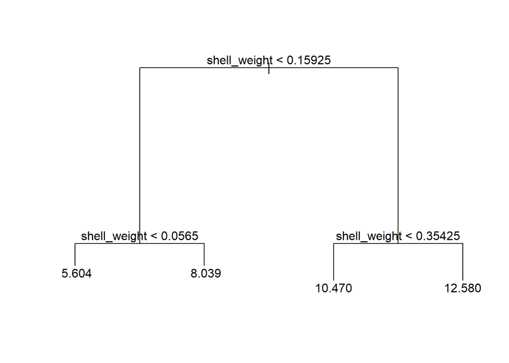

```r
plot(prune_model_rt)
text(prune_model_rt,pretty=0)
```

```r
yhat_prune_full<-(predict(prune_model_rt))
#plot(yhat_prune_full,egitim_data$rings)
egitim_prune_full_rt <- sqrt(mean((egitim_data$rings-yhat_prune_full)^2)) #train performansD1
egitim_prune_full_rt
```

```
## [1] 2.552365
```

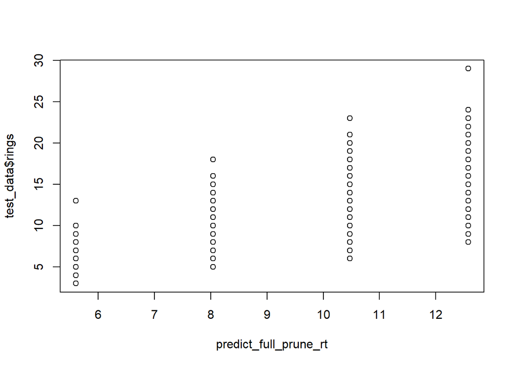

```r
predict_full_prune_rt <- predict(prune_model_rt, test_data)
plot(predict_full_prune_rt,test_data$rings)
```

```r
test_prune_full_rt <-sqrt(mean((test_data$rings-predict_full_prune_rt)^2)) #test performansD1
test_prune_full_rt
```

```
## [1] 2.543681
```

Cross Validation yaparak ağacımızı buduyoruz. Amacımız en optimal seviyede kesmek ve deviance düşük olmasını sağlamak. Bu yüzden best olarak 4 de ağacımızı kestik. Aslında 7’de de kesebilirdik ve deviancemız daha düşük çıkardı. Ama bu seferde test performansının düşük çıkma ihtimalinden dolayı 4’de kesmeye karar verdik. Egitim verisinin RMSE değerine baktığımızda 2.55, test verisinin RMSE değerine baktığımızda ise 2.54 çıktı. RMSE değerlerinde aşırı bir fark olmadı sadece ağaç sadeleşti. Overfitting sorunu olmadığını görmekteyiz.

## 2.3.Bagging ile Regresyon Ağacı (BRT)

```r
library(randomForest)
model_bag <- randomForest(rings~.,data =egitim_data,mtry=8,importance=TRUE)
model_bag
```

```
##
## Call:
##  randomForest(formula = rings ~ ., data = egitim_data, mtry = 8,      importance = TRUE)
##                Type of random forest: regression
##                      Number of trees: 500
## No. of variables tried at each split: 8
##
##           Mean of squared residuals: 4.77664
##                     % Var explained: 54.79
```

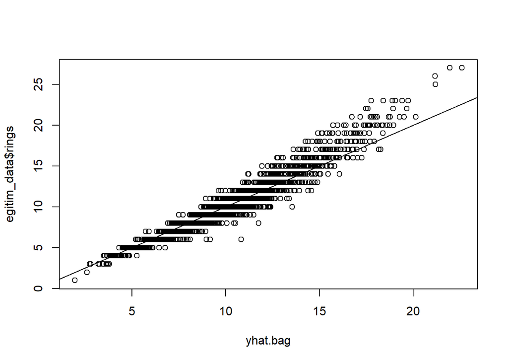

```r
yhat.bag <- predict(model_bag,newdata = egitim_data)
plot(yhat.bag,egitim_data$rings)
abline(0,1)
```

```r
egitim_bag <- sqrt(mean((egitim_data$ring-yhat.bag)^2)) ##rmse değeri
egitim_bag
```

```
## [1] 0.9295602
```

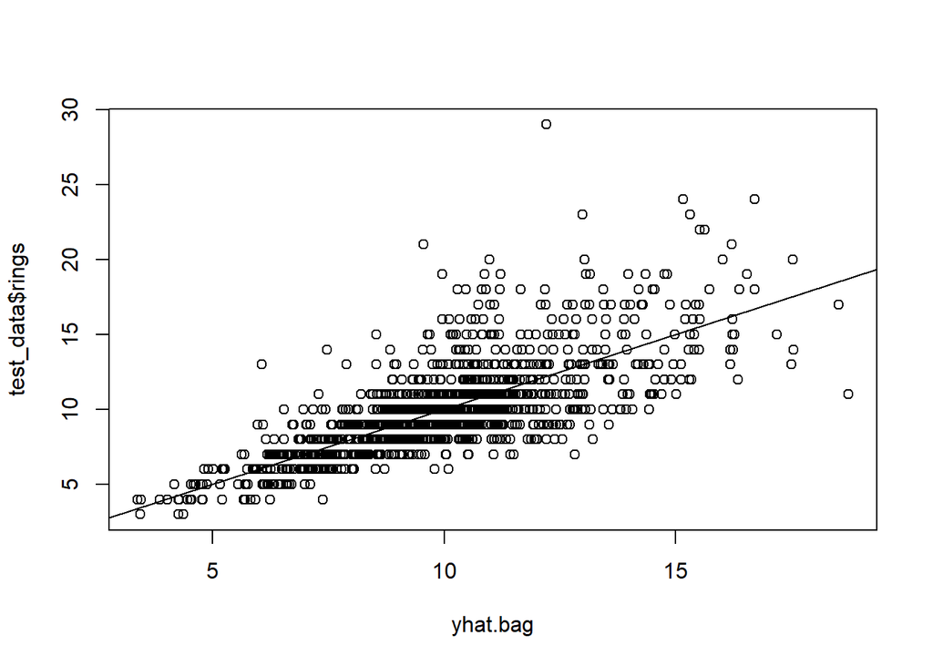

```r
yhat.bag <- predict(model_bag,newdata = test_data)
plot(yhat.bag,test_data$rings)
abline(0,1)
```

```r
test_bag <- sqrt(mean((test_data$ring-yhat.bag)^2))##rmse değeri
test_bag
```

```
## [1] 2.153884
```

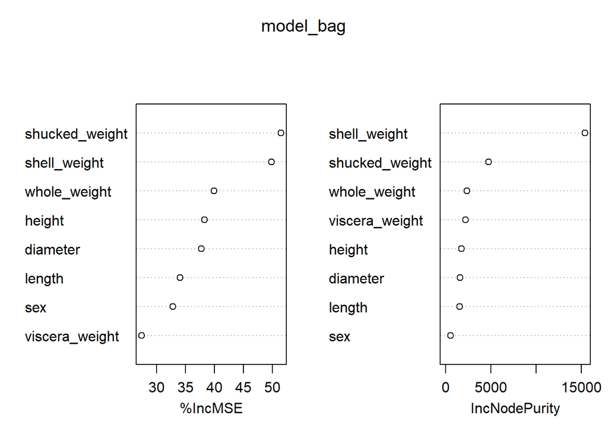

```r
#model_bag$importance
varImpPlot(model_bag)
```

Bagging için tüm değişkenleri (mtry=8) modelimize kattık ve 500 ağaçdan oluşan bir rassal orman modeli oluşturduk. Mean of squared residuals değeri 4.77’dir. Daha düşük bir değer, modelin eğitim verilerinde daha iyi bir uyum sağladığını gösterir. IncMSE yüzdesine baktığımızda, shucked_weight değişkeni çıkarıldığında elde edilen tahminlerdeki ortalama doğruluk düşüşü en fazla olduğu için model için anlamlıdır. Purity yani saflığa baktığımızda da shell_weight, whole_weight, shucked_weight değişkenleri en çok katkıyı sunmuştur. Bagging’deki RMSE değerlerine baktığımızda, eğitim verimizde 0.93, test verimizde ise 2.15 çıkmış. Bu da bize overfitting olabileceğini gösteriyor.

## 2.4.Rassal Ormanlar Regresyonu (RFR)

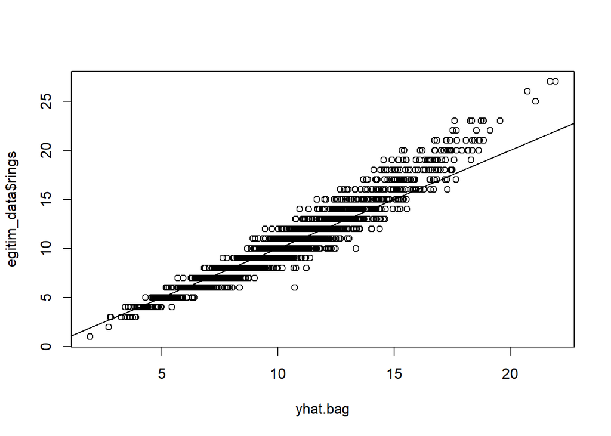

```r
model_rfr <- randomForest(rings~.,data =egitim_data,mtry=3,importance=TRUE)
yhat.bag<-predict(model_rfr,newdata=egitim_data) #train verisi
plot(yhat.bag,egitim_data$rings)
abline(0,1)
```

```r
egitim_rfr <- sqrt(mean((egitim_data$rings-yhat.bag)^2)) #train verisi
egitim_rfr
```

```
## [1] 0.9744229
```

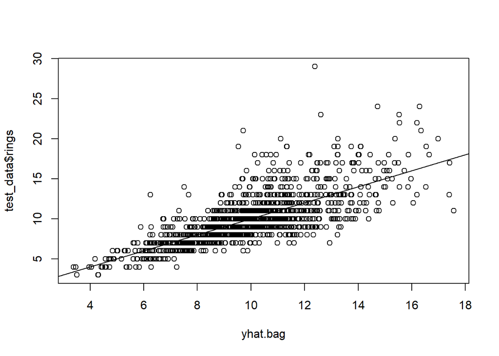

```r
yhat.bag<-predict(model_rfr,newdata=test_data) #test verisi
plot(yhat.bag,test_data$rings)
abline(0,1)
```

```r
test_rfr <- sqrt(mean((test_data$rings-yhat.bag)^2)) #test verisi
test_rfr
```

```
## [1] 2.134526
```

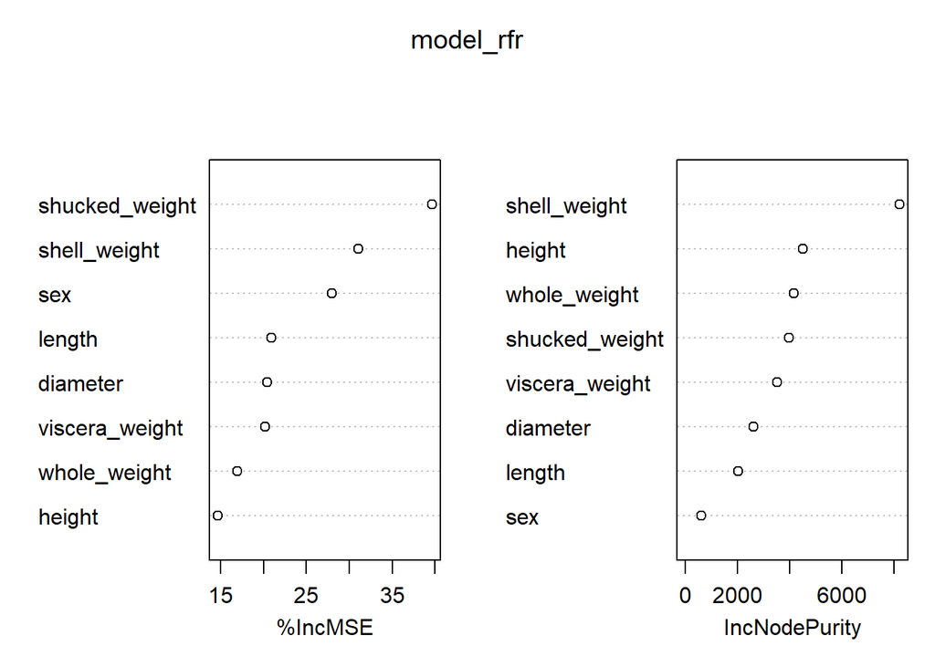

```r
#model_rfr$importance
varImpPlot(model_rfr)
```

Random Forest’ın bagging’den farklı olarak, baggingde mtry=8 tüm bağımsız değişkenleri aldık. Random forestta ise p/3(p değişken sayısı) olarak alıyoruz. Yani burda bize 3 farklı değişken alarak bağımsız ağaçları çiziyor. Daha sonra bu ağaçları bize özetliyor. IncMSE yüzdesine baktığımızda, shucked_weight, shell_weight, sex değişkenleri en çok katkı sunan değişkenlerdir. Purity yani saflığa baktığımızda da shell_weight, height, whole_weight, shucked_weight değişkenleri en çok katkıyı sunmuştur. Random Forest’daki RMSE değerlerine baktığımızda, eğitim verimizde 0.97, test verimizde ise 2.13 çıkmış. Bu da bize overfitting olabileceğini gösteriyor.

## 2.5.Test Verisi Üzerinde Performans Karşılaştırılması

```r
#RMSE DEĞERLERİNİN KARŞILAŞTIRILMASI
cbind(test_model_lm,test_prune_full_rt,test_bag,test_rfr)
```

```
##      test_model_lm test_prune_full_rt test_bag test_rfr
## [1,]      3.971152           2.543681 2.153884 2.134526
```

Modellerin test verileri üzerindeki performansları incelendiğinde, en iyi performansın Rassal Ormanlar Regresyonu ile alındığı görülmektedir. Sonuçta RMSE’ nin en küçük olmasını istiyoruz.